# UNICEF Data Analysis

Author

Keely Thoma

Published

April 19, 2025

## Introduction

Youth well-being is a cornerstone of future development, yet many young people around the world face challenges to health and safety — particularly in rapidly urbanizing regions. In this report, we explore global patterns in youth mortality and urbanization using data from UNICEF.

## Data Overview

```python
import pandas as pd
import numpy as np
from plotnine import *
import matplotlib.pyplot as plt
import geopandas as gpd
import geodatasets

# Import data
indicator1 = pd.read_csv("data/unicef_indicator_1.csv")
indicator2 = pd.read_csv("data/unicef_indicator_2.csv")
metadata = pd.read_csv("data/unicef_metadata.csv")

# print("indicator1 columns:", indicator1.columns.tolist())
# print("indicator2 columns:", indicator2.columns.tolist())
# print("metadata columns:", metadata.columns.tolist())

# Display first few rows of each dataset
print("Indicator 1 Preview:")
display(indicator1.head())

print("\nIndicator 2 Preview:")
display(indicator2.head())

print("\nMetadata Preview:")
display(metadata.head())

# Basic information about the datasets
print("\nIndicator 1 Shape:", indicator1.shape)
print("Indicator 2 Shape:", indicator2.shape)
print("Metadata Shape:", metadata.shape)
```

```
Indicator 1 Preview:
```

|  | country | alpha_2_code | alpha_3_code | numeric_code | indicator | time_period | obs_value | sex | unit_multiplier | unit_of_measure | observation_status | observation_confidentaility | time_period_activity_related_to_when_the_data_are_collected | current_age |
| --- | --- | --- | --- | --- | --- | --- | --- | --- | --- | --- | --- | --- | --- | --- |
| 0 | Afghanistan | AF | AFG | 4 | Annual growth rate of urban population | 2020 | 4.070226 | Total | Units | % | Predicted | NaN | NaN | Total |
| 1 | Albania | AL | ALB | 8 | Annual growth rate of urban population | 2020 | 1.395963 | Total | Units | % | Predicted | NaN | NaN | Total |
| 2 | Algeria | DZ | DZA | 12 | Annual growth rate of urban population | 2020 | 2.630551 | Total | Units | % | Predicted | NaN | NaN | Total |
| 3 | American Samoa | AS | ASM | 16 | Annual growth rate of urban population | 2020 | -1.180811 | Total | Units | % | Predicted | NaN | NaN | Total |
| 4 | Andorra | AD | AND | 20 | Annual growth rate of urban population | 2020 | 0.533492 | Total | Units | % | Predicted | NaN | NaN | Total |

```
Indicator 2 Preview:
```

|  | country | alpha_2_code | alpha_3_code | numeric_code | indicator | time_period | obs_value | sex | unit_multiplier | unit_of_measure | observation_status | observation_confidentaility | time_period_activity_related_to_when_the_data_are_collected | current_age |
| --- | --- | --- | --- | --- | --- | --- | --- | --- | --- | --- | --- | --- | --- | --- |
| 0 | Afghanistan | AF | AFG | 4 | Deaths aged 15 to 24 | 1990 | 6160 | Female | NaN | Number of deaths | Normal value | NaN | NaN | Total |
| 1 | Afghanistan | AF | AFG | 4 | Deaths aged 15 to 24 | 1991 | 5545 | Female | NaN | Number of deaths | Normal value | NaN | NaN | Total |
| 2 | Afghanistan | AF | AFG | 4 | Deaths aged 15 to 24 | 1992 | 5296 | Female | NaN | Number of deaths | Normal value | NaN | NaN | Total |
| 3 | Afghanistan | AF | AFG | 4 | Deaths aged 15 to 24 | 1993 | 5809 | Female | NaN | Number of deaths | Normal value | NaN | NaN | Total |
| 4 | Afghanistan | AF | AFG | 4 | Deaths aged 15 to 24 | 1994 | 5942 | Female | NaN | Number of deaths | Normal value | NaN | NaN | Total |

```
Metadata Preview:
```

|  | country | alpha_2_code | alpha_3_code | numeric_code | year | Population, total | GDP per capita (constant 2015 US$) | GNI (current US$) | Inflation, consumer prices (annual %) | Life expectancy at birth, total (years) | Military expenditure (% of GDP) | Fossil fuel energy consumption (% of total) | GDP growth (annual %) | Birth rate, crude (per 1,000 people) | Hospital beds (per 1,000 people) |
| --- | --- | --- | --- | --- | --- | --- | --- | --- | --- | --- | --- | --- | --- | --- | --- |
| 0 | Afghanistan | AF | AFG | 4 | 1960 | 9035043.0 | NaN | 548888848.9 | NaN | 32.535 | NaN | NaN | NaN | 50.340 | 0.170627 |
| 1 | Afghanistan | AF | AFG | 4 | 1961 | 9214083.0 | NaN | 560000022.2 | NaN | 33.068 | NaN | NaN | NaN | 50.443 | NaN |
| 2 | Afghanistan | AF | AFG | 4 | 1962 | 9404406.0 | NaN | 557777806.7 | NaN | 33.547 | NaN | NaN | NaN | 50.570 | NaN |
| 3 | Afghanistan | AF | AFG | 4 | 1963 | 9604487.0 | NaN | 766666706.7 | NaN | 34.016 | NaN | NaN | NaN | 50.703 | NaN |
| 4 | Afghanistan | AF | AFG | 4 | 1964 | 9814318.0 | NaN | 815555562.2 | NaN | 34.494 | NaN | NaN | NaN | 50.831 | NaN |

```
Indicator 1 Shape: (225, 14)
Indicator 2 Shape: (19701, 14)
Metadata Shape: (13504, 15)
```

## Data Preparation

```python
# Clean and rename columns
urban_growth_clean = indicator1[["country", "alpha_3_code", "obs_value"]].rename(
    columns={"obs_value": "urban_growth_rate"}
)

youth_deaths_total = indicator2[indicator2["sex"] == "Total"]
youth_deaths_yearly = youth_deaths_total.groupby(["country", "time_period"])["obs_value"].sum().reset_index()
youth_deaths_yearly.rename(columns={"obs_value": "total_deaths", "time_period": "year"}, inplace=True)

# Prepare metadata for merging
metadata_clean = metadata.rename(columns={"year": "year"})

# Combine data for scatterplot
combined_data = pd.merge(
    youth_deaths_yearly,
    metadata_clean,
    on=["country", "year"],
    how="inner"
).dropna(subset=["GDP per capita (constant 2015 US$)", "Life expectancy at birth, total (years)"])
```

## Visualization 1: World Map of Urban Growth

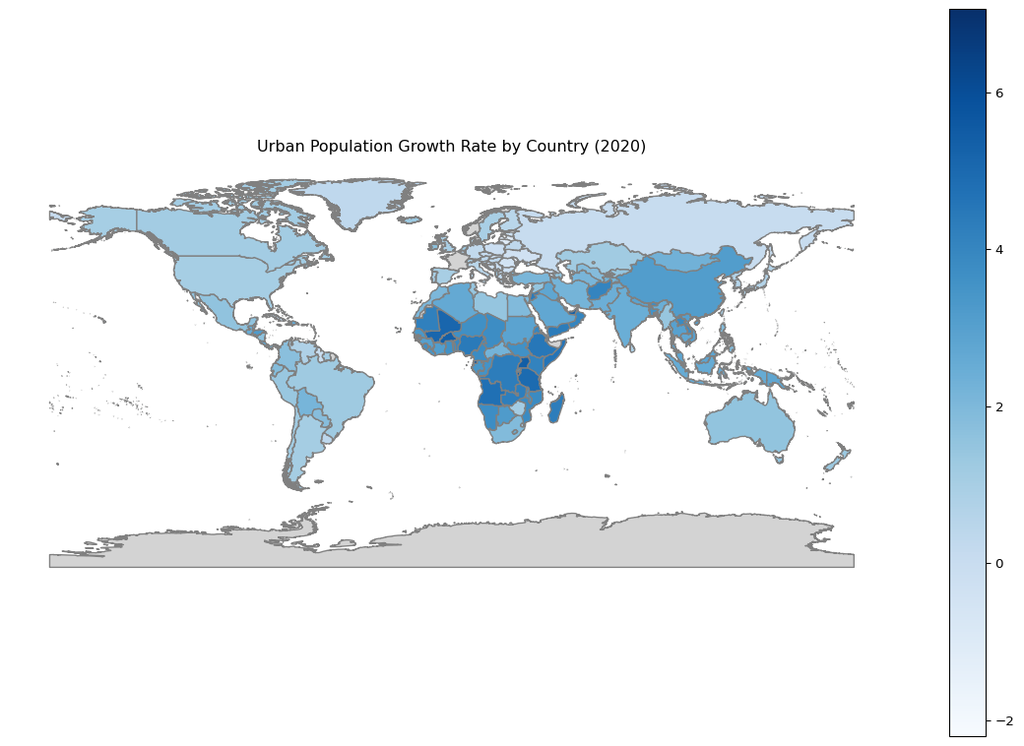

Urban Population Growth Rate by Country (2020)

```python
import pandas as pd
import geopandas as gpd
import matplotlib.pyplot as plt

# — Prep the indicator data —
indicator1 = pd.read_csv("data/unicef_indicator_1.csv")
urban_growth_clean = (
    indicator1[["country","alpha_3_code","obs_value"]]
    .rename(columns={"obs_value":"urban_growth_rate"})
)

# — Load GeoJSON boundaries —
world = gpd.read_file(
    "https://raw.githubusercontent.com/datasets/geo-countries/master/data/countries.geojson"
)
# print(list(world.columns))

# — Merge & Plot —
world_data = world.merge(urban_growth_clean,
                        how="left",
                        left_on="ISO3166-1-Alpha-3",
                        right_on="alpha_3_code")
fig, ax = plt.subplots(figsize=(12,8))
world_data.plot(column="urban_growth_rate",
                cmap="Blues",
                edgecolor="gray",
                legend=True,
                ax=ax,
                missing_kwds={"color":"lightgray","label":"No data"})
ax.set_title("Urban Population Growth Rate by Country (2020)")
ax.axis("off")
plt.tight_layout()
```

## Visualization 2: Bar Chart - Top 10 Countries by Youth Deaths (2020)

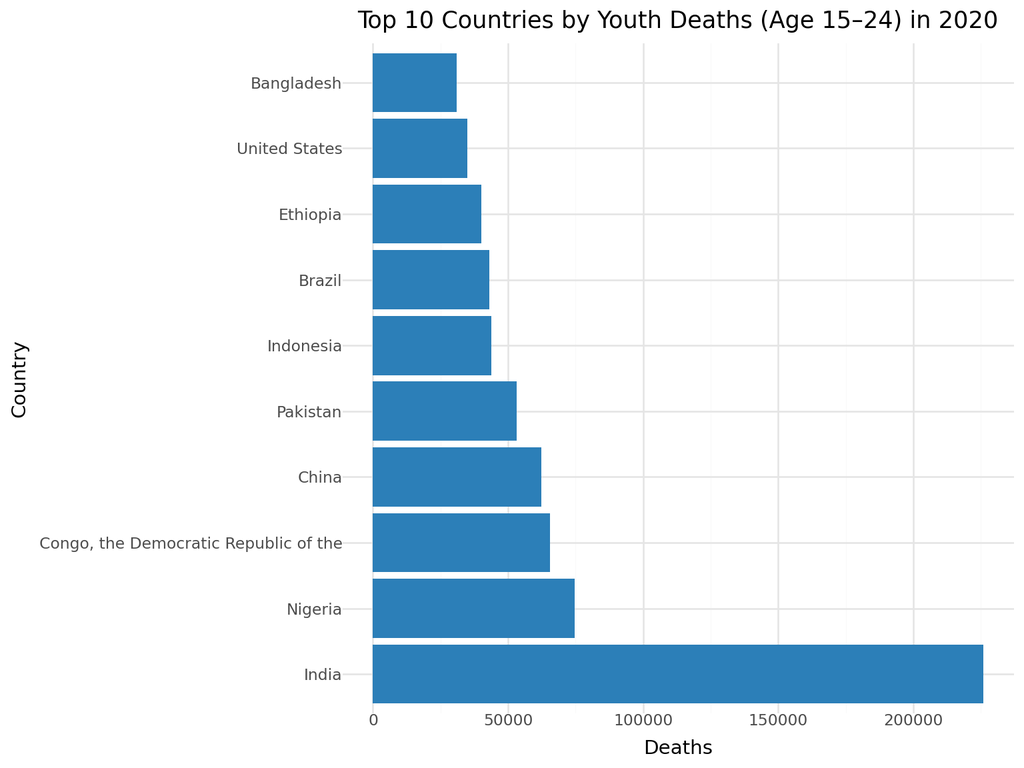

Top 10 Countries by Youth Deaths in 2020

```python
top10_2020 = youth_deaths_yearly[youth_deaths_yearly["year"] == 2020].nlargest(10, "total_deaths")

(
    ggplot(top10_2020, aes(x="reorder(country, -total_deaths)", y="total_deaths"))
    + geom_bar(stat="identity", fill="#2c7fb8")
    + coord_flip()
    + labs(x="Country", y="Deaths", title="Top 10 Countries by Youth Deaths (Age 15–24) in 2020")
    + theme_minimal()
)
```

## Visualization 3: Scatterplot with Regression - Deaths vs GDP

```
        country  year  GDP per capita (constant 2015 US$)  total_deaths
10  Afghanistan  2000                          308.318270          9086
11  Afghanistan  2001                          277.118051          8246
12  Afghanistan  2002                          338.139974          7871
13  Afghanistan  2003                          346.071627          8133
14  Afghanistan  2004                          338.637274          8129
```

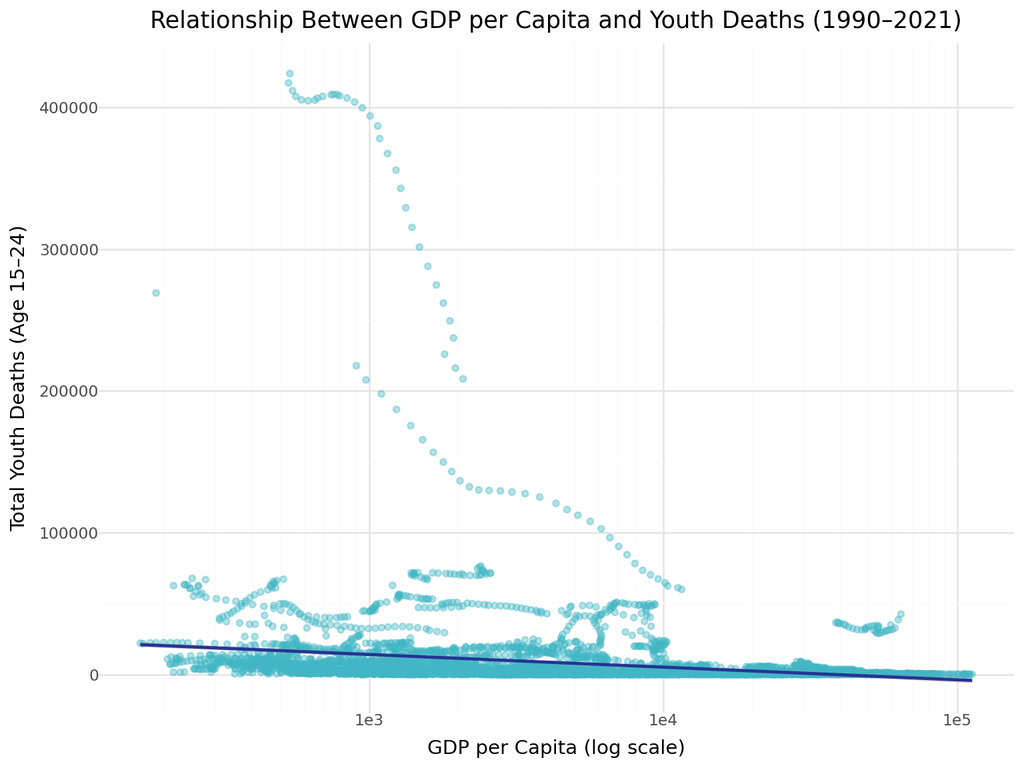

Youth Deaths vs. GDP per Capita (1990–2021)

```python
import pandas as pd
import numpy as np
from plotnine import *
import matplotlib.pyplot as plt
import geopandas as gpd
import geodatasets

# Import data
indicator1 = pd.read_csv("data/unicef_indicator_1.csv")
indicator2 = pd.read_csv("data/unicef_indicator_2.csv")
metadata = pd.read_csv("data/unicef_metadata.csv")

# Prepare metadata for merging
metadata_clean = metadata.rename(columns={"year": "year"})

# Clean and rename columns
urban_growth_clean = indicator1[["country", "alpha_3_code", "obs_value"]].rename(
    columns={"obs_value": "urban_growth_rate"}
)

youth_deaths_total = indicator2[indicator2["sex"] == "Total"]
youth_deaths_yearly = youth_deaths_total.groupby(["country", "time_period"])["obs_value"].sum().reset_index()
youth_deaths_yearly.rename(columns={"obs_value": "total_deaths", "time_period": "year"}, inplace=True)

combined_data = pd.merge(
    youth_deaths_yearly,
    metadata_clean,
    on=["country", "year"],
    how="inner"
).dropna(subset=["GDP per capita (constant 2015 US$)", "Life expectancy at birth, total (years)"])

# Optional: peek at the first few rows to confirm the columns exist
print(combined_data[[
    "country",
    "year",
    "GDP per capita (constant 2015 US$)",
    "total_deaths"
]].head())

# The scatterplot itself
(
    ggplot(combined_data,
           aes(x="GDP per capita (constant 2015 US$)",
               y="total_deaths"))
    + geom_point(alpha=0.4, color="#41b6c4")
    + geom_smooth(method="lm", color="#253494")
    + scale_x_log10()
    + labs(x="GDP per Capita (log scale)",
           y="Total Youth Deaths (Age 15–24)",
           title="Relationship Between GDP per Capita and Youth Deaths (1990–2021)")
    + theme_minimal()
)
```

## Visualization 4: Time Series - Global Youth Deaths Over Time

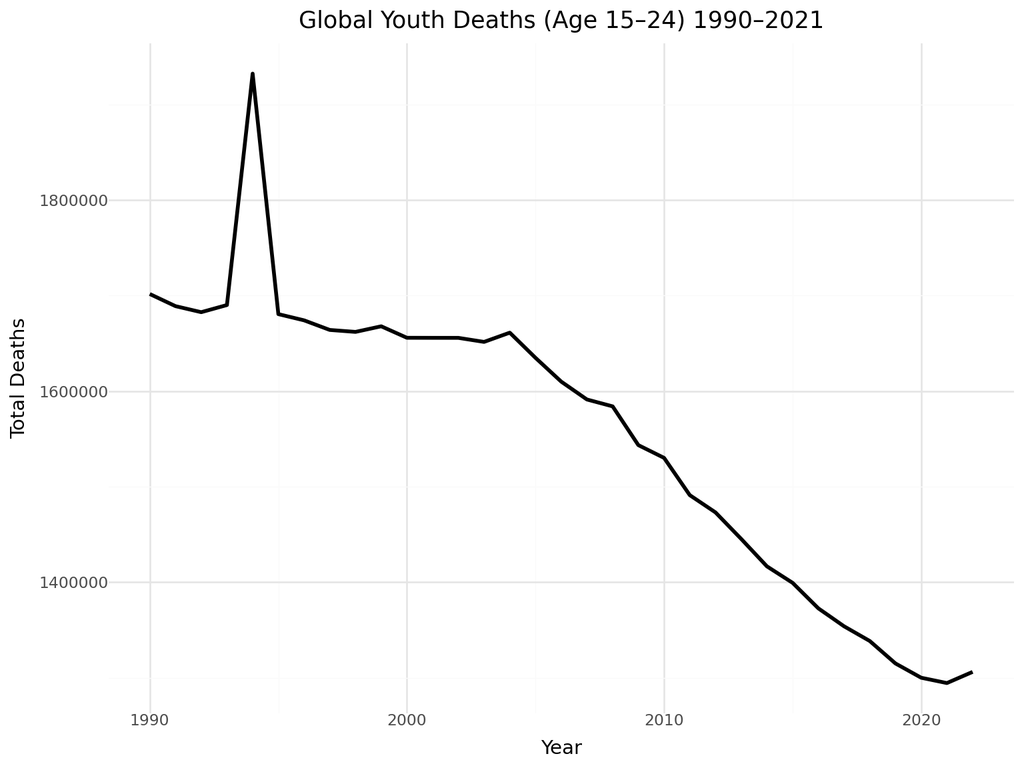

```python
from plotnine import *

global_trend = (
  youth_deaths_yearly
  .groupby("year")["total_deaths"].sum()
  .reset_index()
)

(
  ggplot(global_trend, aes(x="year", y="total_deaths"))
  + geom_line(size=1.2)
  + labs(title="Global Youth Deaths (Age 15–24) 1990–2021",
         x="Year", y="Total Deaths")
  + theme_minimal()
)
```

## Conclusions and Recommendations

Rapid urbanization, if not well-managed, may place stress on healthcare systems and contribute to poor youth outcomes. Countries with low GDP and limited health infrastructure report the highest youth mortality.

To reduce youth deaths, governments should invest in: - Health education and outreach - Adolescent health services - Urban planning and safety programs

Further research should examine regional policies and infrastructure in more detail to explain the observed differences.

## References

- United Nations Children’s Fund (UNICEF). (2023). *State of the World’s Children 2023: For Every Child, Vaccination*. Retrieved from https://www.unicef.org/reports/state-worlds-children-2023
- World Bank. (2023). *World Development Indicators*. Retrieved from https://databank.worldbank.org/source/world-development-indicators
- United Nations. (2018). *World Urbanization Prospects: The 2018 Revision*. Retrieved from https://population.un.org/wup/
- World Health Organization (WHO). (2022). *Global Health Estimates 2022: Deaths by Cause, Age, Sex, by Country and by Region, 2000–2019*. Retrieved from https://www.who.int/data/gho/data/themes/mortality-and-global-health-estimates
- UNICEF Data. (2023). *Monitoring the Situation of Children and Women*. Retrieved from https://data.unicef.org/
- OECD. (2019). *The Future of Urban Development and Youth Inclusion*. Retrieved from https://www.oecd.org/governance/the-future-of-urban-development-and-youth-inclusion.pdf
- World Health Organization (WHO). (2019). *Adolescent Health and Development*. Retrieved from https://www.who.int/maternal_child_adolescent/topics/adolescence/en/
- United Nations Department of Economic and Social Affairs (UN DESA). (2021). *World Social Report 2021: Reconsidering Rural Development*. Retrieved from https://www.un.org/development/desa/dspd/world-social-report/2021-2.html